# In FinTech Mortgage business investment decisions are made based on a house and its rooms. Therefore having the ability to classify the rooms of a house to identify the tyep of room such as diningroom vs bedroom vs et al enables these investment decisions.

# The code in this notebook helps with binary classification of diningroom vs bedroom by using Pretrained Convolutional Neural Networks - Xception in Part 3.

importing Xception Model on 4.3-using-a-pretrained-convnet.ipnb

```python
import keras
keras.__version__
```

```
'2.14.0'
```

importing Xception Model on 4.3-using-a-pretrained-convnet.ipnb Image size = 299 by 299 by 3

```python
from keras.applications import Xception

conv_base = Xception(weights='imagenet',
                  include_top=False,
                  input_shape=(299, 299, 3))
```

```
Downloading data from https://storage.googleapis.com/tensorflow/keras-applications/xception/xception_weights_tf_dim_ordering_tf_kernels_notop.h5
```

```python
conv_base.summary()
```

```
Model: "xception"
__________________________________________________________________________________________________
 Layer (type)                Output Shape                 Param #   Connected to
==================================================================================================
 input_1 (InputLayer)        [(None, 299, 299, 3)]        0         []

 block1_conv1 (Conv2D)       (None, 149, 149, 32)         864       ['input_1[0][0]']

 block1_conv1_bn (BatchNorm  (None, 149, 149, 32)         128       ['block1_conv1[0][0]']
 alization)

 block1_conv1_act (Activati  (None, 149, 149, 32)         0         ['block1_conv1_bn[0][0]']
 on)

 block1_conv2 (Conv2D)       (None, 147, 147, 64)         18432     ['block1_conv1_act[0][0]']

 block1_conv2_bn (BatchNorm  (None, 147, 147, 64)         256       ['block1_conv2[0][0]']
 alization)

 block1_conv2_act (Activati  (None, 147, 147, 64)         0         ['block1_conv2_bn[0][0]']
 on)

 block2_sepconv1 (Separable  (None, 147, 147, 128)        8768      ['block1_conv2_act[0][0]']
 Conv2D)

 block2_sepconv1_bn (BatchN  (None, 147, 147, 128)        512       ['block2_sepconv1[0][0]']
 ormalization)

 block2_sepconv2_act (Activ  (None, 147, 147, 128)        0         ['block2_sepconv1_bn[0][0]']
 ation)

 block2_sepconv2 (Separable  (None, 147, 147, 128)        17536     ['block2_sepconv2_act[0][0]']
 Conv2D)

 block2_sepconv2_bn (BatchN  (None, 147, 147, 128)        512       ['block2_sepconv2[0][0]']
 ormalization)

 conv2d (Conv2D)             (None, 74, 74, 128)          8192      ['block1_conv2_act[0][0]']

 block2_pool (MaxPooling2D)  (None, 74, 74, 128)          0         ['block2_sepconv2_bn[0][0]']
```

[output cut: 343 more lines]

```

 block14_sepconv2 (Separabl  (None, 10, 10, 2048)         3159552   ['block14_sepconv1_act[0][0]']
 eConv2D)

 block14_sepconv2_bn (Batch  (None, 10, 10, 2048)         8192      ['block14_sepconv2[0][0]']
 Normalization)

 block14_sepconv2_act (Acti  (None, 10, 10, 2048)         0         ['block14_sepconv2_bn[0][0]']
 vation)

==================================================================================================
Total params: 20861480 (79.58 MB)
Trainable params: 20806952 (79.37 MB)
Non-trainable params: 54528 (213.00 KB)
__________________________________________________________________________________________________
```

```python
import cv2
from google.colab import drive

drive.mount("/content/gdrive")
```

```python
import os
import numpy as np
from keras.preprocessing.image import ImageDataGenerator


base_dir = '/content/gdrive/MyDrive/ColabNotebooks/House-Room/House-Room-small'

train_dir = os.path.join(base_dir, 'train')
validation_dir = os.path.join(base_dir, 'validation')
test_dir = os.path.join(base_dir, 'test')

datagen = ImageDataGenerator(rescale=1./255)
batch_size = 20

def extract_features(directory, sample_count):
    features = np.zeros(shape=(sample_count, 10, 10, 2048))
    labels = np.zeros(shape=(sample_count))
    generator = datagen.flow_from_directory(
        directory,
        target_size=(299, 299),
        batch_size=batch_size,
        class_mode='binary')
    i = 0
    for inputs_batch, labels_batch in generator:
        features_batch = conv_base.predict(inputs_batch)
        features[i * batch_size : (i + 1) * batch_size] = features_batch
        labels[i * batch_size : (i + 1) * batch_size] = labels_batch
        i += 1
        if i * batch_size >= sample_count:
            # Note that since generators yield data indefinitely in a loop,
            # we must `break` after every image has been seen once.
            break
    return features, labels

train_features, train_labels = extract_features(train_dir, 1000)
validation_features, validation_labels = extract_features(validation_dir, 600)
test_features, test_labels = extract_features(test_dir, 806)
```

```
Found 1000 images belonging to 2 classes.
Found 600 images belonging to 2 classes.
Found 806 images belonging to 2 classes.
```

```python
train_features = np.reshape(train_features, (1000, 10 * 10 * 2048))
validation_features = np.reshape(validation_features, (600, 10 * 10 * 2048))
test_features = np.reshape(test_features, (806, 10 * 10 * 2048))
```

```python
from keras import models
from keras import layers
from keras import optimizers

model = models.Sequential()
model.add(layers.Dense(256, activation='relu', input_dim=10 * 10 * 2048))
model.add(layers.Dropout(0.5))
model.add(layers.Dense(1, activation='sigmoid'))

model.compile(optimizer=optimizers.RMSprop(lr=2e-5),
              loss='binary_crossentropy',
              metrics=['acc'])

history = model.fit(train_features, train_labels,
                    epochs=30,
                    batch_size=20,
                    validation_data=(validation_features, validation_labels))
```

```
WARNING:absl:`lr` is deprecated in Keras optimizer, please use `learning_rate` or use the legacy optimizer, e.g.,tf.keras.optimizers.legacy.RMSprop.
```

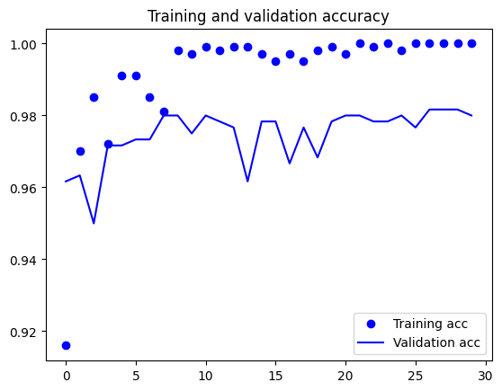

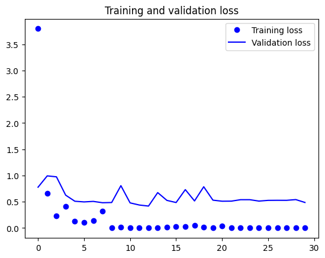

```python
import matplotlib.pyplot as plt

acc = history.history['acc']
val_acc = history.history['val_acc']
loss = history.history['loss']
val_loss = history.history['val_loss']

epochs = range(len(acc))

plt.plot(epochs, acc, 'bo', label='Training acc')
plt.plot(epochs, val_acc, 'b', label='Validation acc')
plt.title('Training and validation accuracy')
plt.legend()

plt.figure()

plt.plot(epochs, loss, 'bo', label='Training loss')
plt.plot(epochs, val_loss, 'b', label='Validation loss')
plt.title('Training and validation loss')
plt.legend()

plt.show()
```

```python
from keras import models
from keras import layers

model = models.Sequential()
model.add(conv_base)
model.add(layers.Flatten())
model.add(layers.Dense(256, activation='relu'))
model.add(layers.Dense(1, activation='sigmoid'))
```

```python
model.summary()
```

```
Model: "sequential_1"
_________________________________________________________________
 Layer (type)                Output Shape              Param #
=================================================================
 xception (Functional)       (None, 10, 10, 2048)      20861480

 flatten (Flatten)           (None, 204800)            0

 dense_2 (Dense)             (None, 256)               52429056

 dense_3 (Dense)             (None, 1)                 257

=================================================================
Total params: 73290793 (279.58 MB)
Trainable params: 73236265 (279.37 MB)
Non-trainable params: 54528 (213.00 KB)
_________________________________________________________________
```

```python
print('This is the number of trainable weights '
      'before freezing the conv base:', len(model.trainable_weights))
```

```
This is the number of trainable weights before freezing the conv base: 158
```

```python
conv_base.trainable = False
```

```python
print('This is the number of trainable weights '
      'after freezing the conv base:', len(model.trainable_weights))
```

```
This is the number of trainable weights after freezing the conv base: 4
```

```python
from keras.preprocessing.image import ImageDataGenerator

train_datagen = ImageDataGenerator(
      rescale=1./255,
      rotation_range=40,
      width_shift_range=0.2,
      height_shift_range=0.2,
      shear_range=0.2,
      zoom_range=0.2,
      horizontal_flip=True,
      fill_mode='nearest')

# Note that the validation data should not be augmented!
test_datagen = ImageDataGenerator(rescale=1./255)

train_generator = train_datagen.flow_from_directory(
        # This is the target directory
        train_dir,
        # All images will be resized to 150x150
        target_size=(299, 299),
        batch_size=20,
        # Since we use binary_crossentropy loss, we need binary labels
        class_mode='binary')

validation_generator = test_datagen.flow_from_directory(
        validation_dir,
        target_size=(299, 299),
        batch_size=20,
        class_mode='binary')

model.compile(loss='binary_crossentropy',
              optimizer=optimizers.RMSprop(lr=2e-5),
              metrics=['acc'])

history = model.fit_generator(
      train_generator,
      steps_per_epoch=50,
      epochs=30,
      validation_data=validation_generator,
      validation_steps=30,
      verbose=2)
```

```
Found 1000 images belonging to 2 classes.
Found 600 images belonging to 2 classes.
```

```
WARNING:absl:`lr` is deprecated in Keras optimizer, please use `learning_rate` or use the legacy optimizer, e.g.,tf.keras.optimizers.legacy.RMSprop.
```

```
50/50 - 34s - loss: 5.5773 - acc: 0.8220 - val_loss: 0.3609 - val_acc: 0.9650 - 34s/epoch - 690ms/step
50/50 - 29s - loss: 0.9334 - acc: 0.8930 - val_loss: 0.4817 - val_acc: 0.9367 - 29s/epoch - 583ms/step
50/50 - 30s - loss: 0.5672 - acc: 0.9210 - val_loss: 0.2594 - val_acc: 0.9700 - 30s/epoch - 608ms/step
50/50 - 31s - loss: 0.4968 - acc: 0.9230 - val_loss: 1.5760 - val_acc: 0.8450 - 31s/epoch - 627ms/step
50/50 - 31s - loss: 0.5014 - acc: 0.9170 - val_loss: 0.3623 - val_acc: 0.9550 - 31s/epoch - 612ms/step
50/50 - 28s - loss: 0.2394 - acc: 0.9450 - val_loss: 0.1265 - val_acc: 0.9683 - 28s/epoch - 560ms/step
50/50 - 30s - loss: 0.2878 - acc: 0.9260 - val_loss: 0.1153 - val_acc: 0.9683 - 30s/epoch - 601ms/step
50/50 - 30s - loss: 0.1974 - acc: 0.9400 - val_loss: 0.1644 - val_acc: 0.9600 - 30s/epoch - 606ms/step
50/50 - 28s - loss: 0.1332 - acc: 0.9470 - val_loss: 0.0995 - val_acc: 0.9683 - 28s/epoch - 564ms/step
50/50 - 30s - loss: 0.1608 - acc: 0.9630 - val_loss: 0.1711 - val_acc: 0.9633 - 30s/epoch - 608ms/step
50/50 - 30s - loss: 0.1269 - acc: 0.9550 - val_loss: 0.1836 - val_acc: 0.9700 - 30s/epoch - 593ms/step
50/50 - 28s - loss: 0.1579 - acc: 0.9410 - val_loss: 0.1037 - val_acc: 0.9700 - 28s/epoch - 563ms/step
50/50 - 31s - loss: 0.1219 - acc: 0.9610 - val_loss: 0.2107 - val_acc: 0.9633 - 31s/epoch - 620ms/step
50/50 - 31s - loss: 0.1065 - acc: 0.9600 - val_loss: 0.1083 - val_acc: 0.9717 - 31s/epoch - 616ms/step
50/50 - 28s - loss: 0.1231 - acc: 0.9550 - val_loss: 0.1131 - val_acc: 0.9750 - 28s/epoch - 564ms/step
50/50 - 31s - loss: 0.1230 - acc: 0.9580 - val_loss: 0.0822 - val_acc: 0.9750 - 31s/epoch - 623ms/step
50/50 - 29s - loss: 0.1055 - acc: 0.9640 - val_loss: 0.1070 - val_acc: 0.9700 - 29s/epoch - 577ms/step
50/50 - 30s - loss: 0.1315 - acc: 0.9620 - val_loss: 0.0773 - val_acc: 0.9767 - 30s/epoch - 600ms/step
50/50 - 31s - loss: 0.1004 - acc: 0.9670 - val_loss: 0.1347 - val_acc: 0.9700 - 31s/epoch - 614ms/step
50/50 - 31s - loss: 0.1507 - acc: 0.9580 - val_loss: 0.1274 - val_acc: 0.9683 - 31s/epoch - 618ms/step
50/50 - 30s - loss: 0.1178 - acc: 0.9630 - val_loss: 0.1008 - val_acc: 0.9733 - 30s/epoch - 610ms/step
50/50 - 28s - loss: 0.1061 - acc: 0.9670 - val_loss: 0.0973 - val_acc: 0.9717 - 28s/epoch - 564ms/step
50/50 - 30s - loss: 0.1218 - acc: 0.9540 - val_loss: 0.1363 - val_acc: 0.9667 - 30s/epoch - 605ms/step
50/50 - 30s - loss: 0.0835 - acc: 0.9650 - val_loss: 0.1400 - val_acc: 0.9717 - 30s/epoch - 607ms/step
50/50 - 31s - loss: 0.1058 - acc: 0.9670 - val_loss: 0.1228 - val_acc: 0.9717 - 31s/epoch - 610ms/step
50/50 - 31s - loss: 0.0832 - acc: 0.9720 - val_loss: 0.1168 - val_acc: 0.9683 - 31s/epoch - 622ms/step
50/50 - 28s - loss: 0.0905 - acc: 0.9680 - val_loss: 0.1025 - val_acc: 0.9733 - 28s/epoch - 563ms/step
50/50 - 31s - loss: 0.0842 - acc: 0.9660 - val_loss: 0.1241 - val_acc: 0.9733 - 31s/epoch - 623ms/step
50/50 - 30s - loss: 0.0540 - acc: 0.9840 - val_loss: 0.1420 - val_acc: 0.9750 - 30s/epoch - 593ms/step
50/50 - 29s - loss: 0.0867 - acc: 0.9650 - val_loss: 0.1237 - val_acc: 0.9717 - 29s/epoch - 575ms/step
```

```python
model.save('/content/gdrive/MyDrive/ColabNotebooks/final_project/final_project_6_Xception.h5')
```

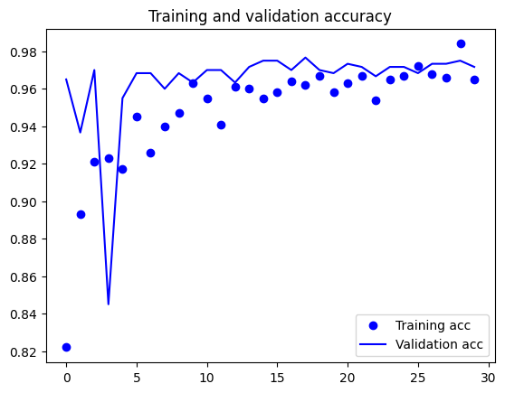

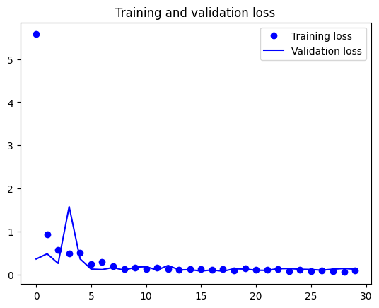

```python
acc = history.history['acc']
val_acc = history.history['val_acc']
loss = history.history['loss']
val_loss = history.history['val_loss']

epochs = range(len(acc))

plt.plot(epochs, acc, 'bo', label='Training acc')
plt.plot(epochs, val_acc, 'b', label='Validation acc')
plt.title('Training and validation accuracy')
plt.legend()

plt.figure()

plt.plot(epochs, loss, 'bo', label='Training loss')
plt.plot(epochs, val_loss, 'b', label='Validation loss')
plt.title('Training and validation loss')
plt.legend()

plt.show()
```